# Discussion: Méthodes de Monte-Carlo avec réduction de variance

Évaluation d’options sous volatilité stochastique

Sabrina Guerrier

30 avril 2025

# Contexte et motivation

- **Limite fondamentale du modèle de Black-Scholes-Merton (1974)**  
  → Postulat de volatilité constante incompatible avec le phénomène empirique de *smile* de volatilité:
  - Variations systématiques de volatilité implicite selon le prix d’exercice et l’échéance.
- **Solution théorique : modèles à volatilité stochastique**  
  → Exemple canonique : Heston (1993)
  - Volatilité pilotée par un processus stochastique (ex : processus d’Ornstein-Uhlenbeck)
  - Avantage empirique :
    - Reproduction des dynamiques de marché observées :
      - Niveau, pente et convexité du smile
      - Structure temporelle de la volatilité
  - Défis de calcul:
    - Solutions analytiques rares sous volatilité stochastique
    - Méthodes numériques nécessaires, notamment Monte Carlo
    - Convergence lente des simulations Monte Carlo standard en $\mathcal{O}(1/\sqrt{N})$

# Parcours personnel avec ce sujet

- **Premiers pas** : simulations Monte Carlo en VBA dans ADM4751, pour estimer la volatilité implicite (méthode de Newton-Raphson). Approche technique sans recul critique.
- **Projet final 2024** : Confrontation au sourire de volatilité. Prise de conscience des limites de Black-Scholes. Introduction à la tension entre théorie et réalité des marchés.
- **Prolongement actuel** : Étude des processus stochastiques, changement de mesure, importance sampling. Base formelle pour comprendre les modèles à volatilité stochastique et expérimenter avec implémentation simple en R, en intégrant des outils vus dans MAT4372.
- **Objectif personnel dans cette discussion** :  
  Comprendre comment simplifier un modèle stochastique tout en restant fidèle à l’intuition de Black-Scholes-Merton, et explorer les compromis entre réalisme empirique, clarté théorique et faisabilité numérique.

# Orientation de la discussion

- **Article de référence : Fouque & Tullie (2001)**  
  → Proposition centrale :
  - Exploiter l’*approximation asymptotique* lorsque la volatilité revient rapidement vers sa moyenne (fort taux de reversion $\alpha$).
  - Si la volatilité fluctue rapidement autour d’un niveau moyen, on peut approximer le prix d’option avec une formule de type Black-Scholes, en remplaçant la volatilité par une volatilité effective (moyenne pondérée dans le temps). → Avantage pratique :
  - Réduction significative de la variance en simulations Monte Carlo
  - Bonne précision même lorsque $\alpha$ n’est pas extrêmement élevé
  - Cette approche permet de réduire la variance des simulations et d’accélérer les calculs.

# 1. Fondements théoriques

## 1.1 Modèles à volatilité stochastique

Modèle de type Heston, tel que défini par les équations (2.1) et (2.4) dans Fouque & Tullie (2001) : - Dynamique du prix de l’actif (équation 2.1) :

$$d X_t=\mu X_t d t+\sigma\left(Y_t\right) X_t d W_t$$

- Processus de volatilité de type Ornstein-Uhlenbeck (équation 2.4) :

$$d Y_t=\alpha\left(m-Y_t\right) d t+\nu \sqrt{2 \alpha}\left(\rho d
W_t+\sqrt{1-\rho^2} d Z_t\right)$$

> **Note :** Note pédagogique : Le code suivant répète intentionnellement certaines déclarations pour faciliter la lisibilité section par section. En pratique, on optimiserait avec des fonctions. Mais ici, j’ai essayé de privilégier la transparence sur les étapes individuelles.

### Application pratique 1.1: Simulation - processus d’Ornstein-Uhlenbeck

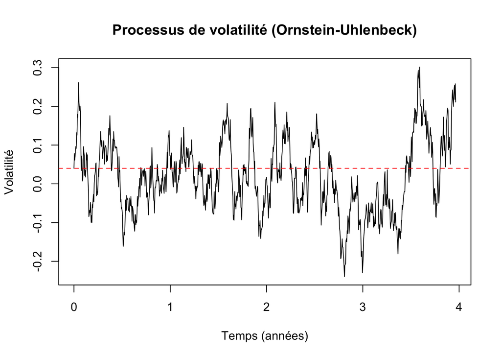

```r
# Paramètres de base pour l'actif et le processus de volatilité
mu <- 0.05    # Taux de rendement espéré de l'actif
r <- 0.02     # Taux sans risque
S_0 <- 100    # Prix initial de l'actif

# Paramètres du processus de volatilité stochastique (processus OU)
alpha <- 10   # Vitesse de réversion vers la moyenne
m <- 0.04     # Moyenne de long terme (niveau de réversion du processus)
nu <- 0.1     # Amplitude des fluctuations de la volatilité (paramètre de diffusion)
rho <- -0.5   # Corrélation entre le bruit du prix de l'actif et celui de la volatilité

dt <- 1/252   # Pas de temps quotidien (252 jours de bourse par an)

# Simulation du processus de volatilité
set.seed(42)  # Pour assurer la reproductibilité

Y <- numeric(1000)  # Vecteur contenant la trajectoire de la volatilité
Y[1] <- m           # Condition initiale du processus - Définition de la moyenne de long terme

# Boucle de simulation d'un processus d'Ornstein-Uhlenbeck
for(i in 2:1000) {
  Y[i] <- Y[i-1] + alpha * (m - Y[i-1]) * dt +
          nu * sqrt(2 * alpha) * sqrt(dt) * rnorm(1)
}

# Création de l'axe temporel (en années)
time_grid <- seq(0, (length(Y) - 1) * dt, by = dt)

# Visualisation du processus simulé
plot(time_grid, Y, type = "l",
     main = "Processus de volatilité (Ornstein-Uhlenbeck)",
     xlab = "Temps (années)",
     ylab = "Volatilité")
abline(h = m, col = "red", lty = 2)  # Ligne pointillée à la moyenne de long terme
```

## 1.2 Concept de réversion rapide

- Lorsque $\alpha$ est grand, $Y_t$ oscille rapidement autour de sa moyenne.
- Cela justifie l’approximation par une volatilité effective.
- On peut alors développer des solutions asymptotiques (voir section 2.3 de Fouque & Tullie).

### Application pratique 1.2: Effet de la vitesse de réversion $\alpha$

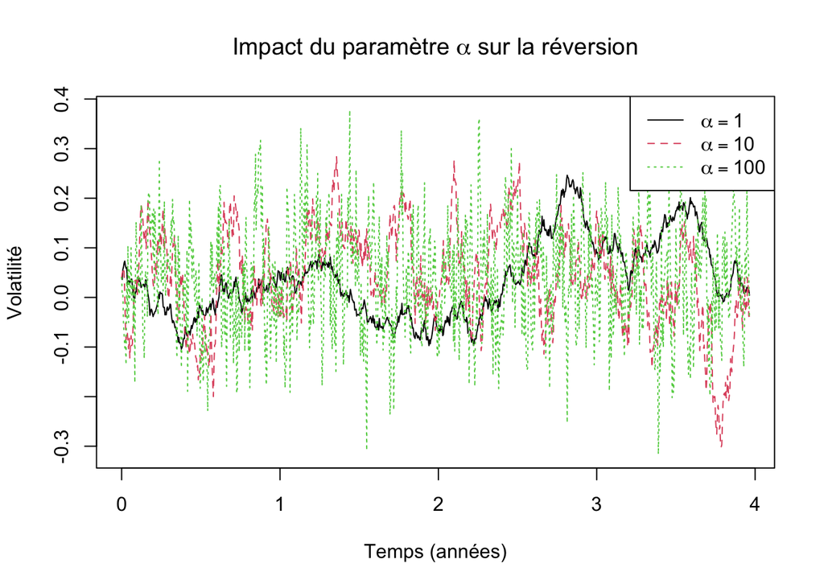

```r
# On compare ici l'effet de différentes valeurs de alpha (vitesse de réversion)
alpha_values <- c(1, 10, 100)       # Trois régimes : lent, modéré, rapide
Y_matrix <- matrix(0, nrow=1000, ncol=3)  # Matrice pour stocker les trajectoires simulées

# Simulation pour chaque valeur de alpha
for(j in 1:3) {
  Y_matrix[1, j] <- m
  for(i in 2:1000) {
    Y_matrix[i, j] <- Y_matrix[i-1, j] +
                      alpha_values[j] * (m - Y_matrix[i-1, j]) * dt +
                      nu * sqrt(2 * alpha_values[j]) * sqrt(dt) * rnorm(1)
  }
}

# Création d'un axe de temps exprimé en années
time_grid <- seq(0, (nrow(Y_matrix) - 1) * dt, by = dt)

# Visualisation comparative
matplot(time_grid, Y_matrix, type="l", lty=1:3, col=1:3,
        main=expression("Impact du paramètre " * alpha * " sur la réversion"),
        xlab="Temps (années)",
        ylab="Volatilité")

# Légende indiquant les valeurs de alpha utilisées
legend("topright", legend=c(expression(alpha==1),
                            expression(alpha==10),
                            expression(alpha==100)),
       lty=1:3, col=1:3)
```

# 2. Évaluation d’options

## 2.1 Approche risque-neutre

- Prix d’une option européenne sous mesure risque-neutre:
  $$P(t,x,y) =
  \mathbb{E}^{\mathbb{Q}}\left[e^{-r(T-t)}\phi(X_T)\,|\,X_t=x,
  Y_t=y\right]$$

où: - $\mathbb{E}^{\mathbb{Q}}$ est l’espérance sous la mesure risque-neutre - $r$ est le taux sans risque - $\phi(X_T)$ est le profil de gain (payoff) de l’option à maturité - $X_t$ est le prix de l’actif à l’instant $t$ - $Y_t$ est le niveau de volatilité à l’instant $t$

### 2.2 Simulation Monte Carlo : description de la méthode

Dans le contexte d’évaluation d’options sous volatilité stochastique, la méthode Monte Carlo standard consiste à:

1. Générer $N$ trajectoires du couple $(X_t, Y_t)$ par la méthode d’Euler
   - Discrétisation d’équation différentielle sstochastique (EDS) via méthode d’Euler (Hull,2018)
     - Processus de volatilité :
       $$Y_{t+\Delta t}=Y_t+\alpha\left(m-Y_t\right) \Delta t+\nu \sqrt{2
       \alpha} \Delta Z_t$$
       où $\Delta Z_t=\rho \Delta W_t^1+\sqrt{1-\rho^2} \Delta W_t^2$.
     - Processus de prix (risque-neutre) :
       $$\ln X_{t+\Delta t}=\ln X_t+\left(r-\frac{1}{2} Y_t\right) \Delta
       t+\sqrt{Y_t} \Delta W_t^1$$
2. Calculer le profil de gain (payoff) à maturité pour chaque trajectoire
3. Actualiser les payoffs au taux sans risque
4. Estimer le prix comme la moyenne empirique des payoffs actualisés

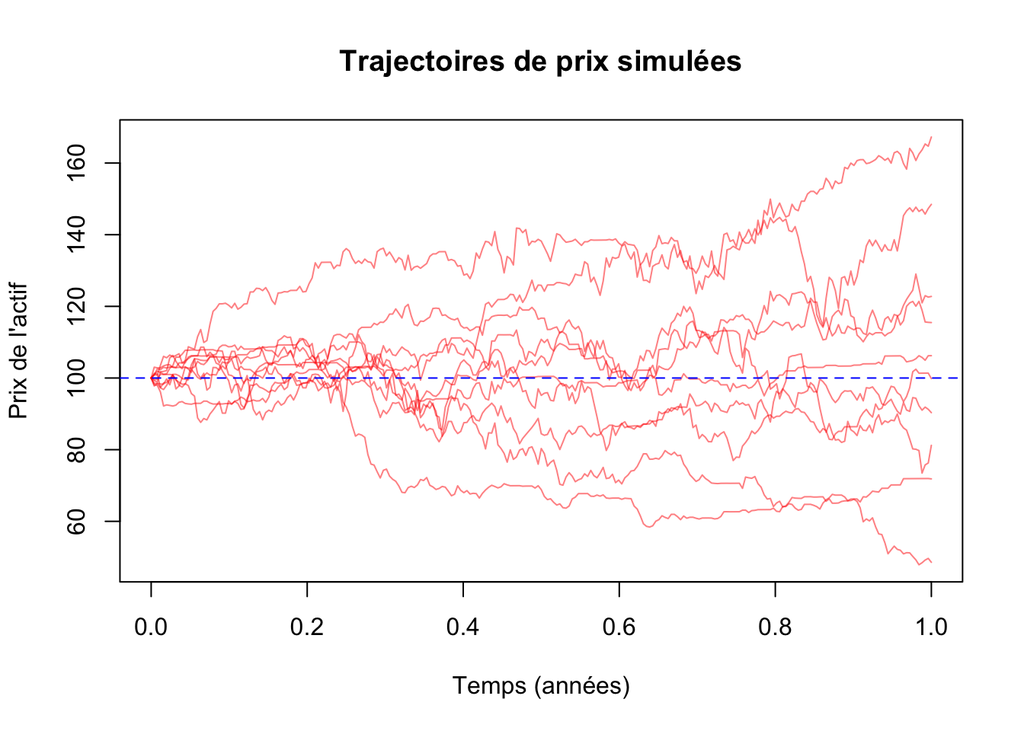

```r
# Paramètres pour la simulation Monte Carlo
T <- 1           # Maturité de l'option (en années)
K <- 100         # Prix d'exercice de l'option
n_steps <- 252   # Nombre de pas de temps (un an de jours ouvrables)
n_paths <- 5000  # Nombre de trajectoires à simuler
v0 <- m          # Volatilité initiale (égale à la moyenne à long terme)

# Initialisation des matrices pour les trajectoires
set.seed(123)    # Pour la reproductibilité

# Génération des incréments browniens corrélés pour les processus de prix et de volatilité
W1 <- matrix(rnorm(n_steps * n_paths), nrow = n_steps)
W2 <- matrix(rnorm(n_steps * n_paths), nrow = n_steps)
Z1 <- W1
Z2 <- rho * W1 + sqrt(1 - rho^2) * W2

# Matrices pour la trajectoire sans changement de mesure (nominal)
S_nominal <- matrix(0, nrow = n_steps + 1, ncol = n_paths)
v_nominal <- matrix(0, nrow = n_steps + 1, ncol = n_paths)

# Conditions initiales
S_nominal[1, ] <- S_0
v_nominal[1, ] <- v0

# Simulation des trajectoires via schéma d'Euler (volatilité) et formule exacte (prix)
# Voir les équations en section "Discrétisation des EDS" pour les détails théoriques.
for (i in 1:n_steps) {
  # Mise à jour de la volatilité (processus OU)
  v_nominal[i+1, ] <- v_nominal[i, ] + alpha*(m - v_nominal[i, ])*dt +
                      nu*sqrt(2*alpha)*sqrt(dt)*Z2[i, ]

  # Forcer la positivité de la variance - justification:
  # Le processus OU peut devenir négatif, ce qui n'est pas réaliste pour une variance
  # Cette correction est une approximation pratique, bien que théoriquement imparfaite
  v_nominal[i+1, ] <- pmax(v_nominal[i+1, ], 0)

  # Mise à jour du prix de l'actif sous mesure risque-neutre
  # Utilisation de la formule exacte pour le log-prix.
  # L'objectif est de réduire l'erreur de discrétisation et assure la positivité des prix.
  S_nominal[i+1, ] <- S_nominal[i, ] * exp((r - 0.5*v_nominal[i, ])*dt +
                                           sqrt(v_nominal[i, ]*dt)*Z1[i, ])
}

# Visualisation de quelques trajectoires de prix simulées
time_grid_full <- seq(0, T, length.out = n_steps + 1)
matplot(time_grid_full, S_nominal[,1:10], type="l",
        col=rgb(1,0,0,0.5), lty=1,
        main="Trajectoires de prix simulées",
        xlab="Temps (années)",
        ylab="Prix de l'actif")
abline(h=K, col="blue", lty=2)  # Prix d'exercice
```

## 2.3 Application à l’option digitale

Une option digitale (ou binaire) paie 1 unité monétaire si l’actif sous-jacent termine au-dessus du prix d’exercice $K$, et 0 sinon. Son payoff est:

$$\phi(X_T) = \mathbf{1}_{\{X_T >
K\}}$$

Ce payoff discontinu rend l’évaluation par Monte Carlo particulièrement difficile en raison de la variance élevée.

```r
# Calcul du payoff pour l'option digitale
payoff_digital <- (S_nominal[n_steps+1,] > K)

# Estimation du prix par Monte Carlo standard
price_digital_std <- mean(exp(-r*T) * payoff_digital)
std_error_digital_std <- sd(exp(-r*T) * payoff_digital) / sqrt(n_paths)

cat("Option digitale - Monte Carlo standard:\n")
```

```
## Option digitale - Monte Carlo standard:
```

```r
cat("Prix estimé:", round(price_digital_std, 6), "\n")
```

```
## Prix estimé: 0.479905
```

```r
cat("Écart-type:", round(std_error_digital_std, 6), "\n")
```

```
## Écart-type: 0.00693
```

```r
cat("Intervalle de confiance à 95%: [",
    round(price_digital_std - 1.96*std_error_digital_std, 6), ", ",
    round(price_digital_std + 1.96*std_error_digital_std, 6), "]\n")
```

```
## Intervalle de confiance à 95%: [ 0.466322 ,  0.493489 ]
```

# 3. Réduction de variance

## 3.1 Principe de l’échantillonnage d’importance

L’échantillonnage d’importance (*importance sampling*) est une technique de réduction de variance qui repose sur deux étapes principales :

- **Étape 1 : Modification de la probabilité des trajectoires**
  - On simule les trajectoires sous une mesure de probabilité modifiée.
  - Cette mesure favorise les trajectoires qui contribuent fortement à l’espérance recherchée.
  - Exemple : dans une option digitale, on augmente artificiellement la fréquence des trajectoires où le prix de l’actif dépasse le prix d’exercice.
- **Étape 2 : Correction du biais introduit**
  - On applique un facteur de pondération à chaque trajectoire simulée.
  - Ce facteur ajuste les résultats pour qu’ils reflètent fidèlement la distribution d’origine.
  - Il est calculé à l’aide de la **densité de Radon-Nikodym**, qui mesure la différence entre la mesure modifiée et la mesure initiale.
- **Interprétation dans le contexte des options**
  - On modifie généralement la dérive (**drift**) du processus de prix pour rendre certains résultats (comme le dépassement du prix d’exercice) plus probables.
  - Le **facteur correcteur** dépend :
    - de la valeur ajoutée au drift,
    - des incréments simulés du bruit aléatoire (les mouvements browniens),
    - de la durée de la simulation.
- **Référence théorique**
  - Le calcul de ce facteur s’appuie sur le **théorème de Girsanov**.
  - Celui-ci décrit comment relier deux mesures de probabilité quand on modifie le drift d’un processus stochastique.
  - Dans le cas d’un drift constant, le facteur de correction prend une forme exponentielle simple.

> **Note :** La formule mathématique exacte (habituellement exprimée à l’aide d’intégrales stochastiques) a été volontairement omise ici. J’ai opté pour cette simplification pour préserver la lisibilité tout en me permettant d’exprimer l’intuition du modèle. Formules complètes consultées dans notes des cours 18-19) et Fouque & Tullie (2001).

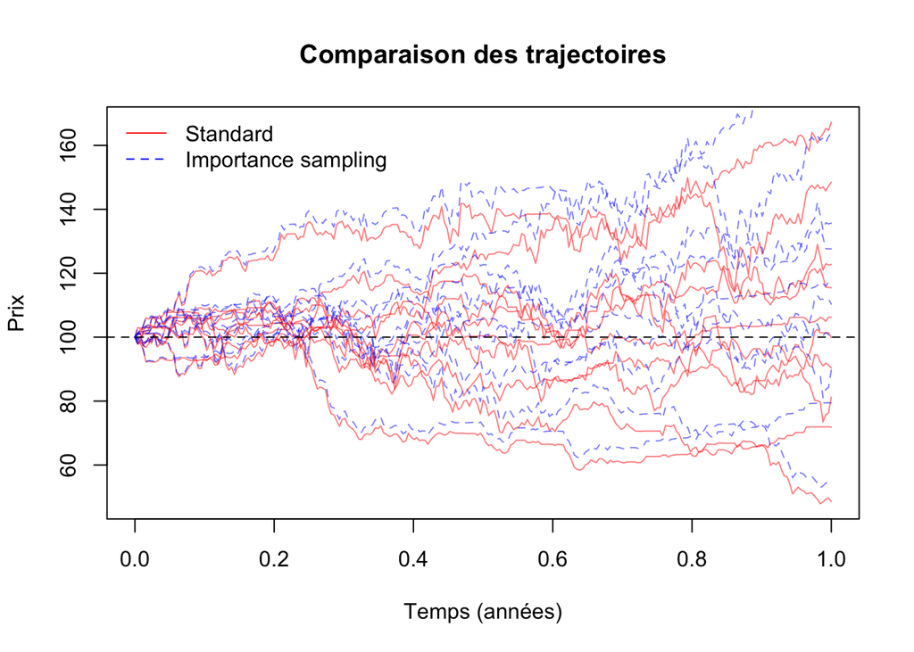

```r
# Paramètre pour l'importance sampling
mu_shift <- 0.1  # Décalage du drift pour importance sampling
# Justification du choix: Cette valeur a été choisie pour augmenter la probabilité
# que le prix franchisse le seuil K, tout en maintenant un équilibre entre
# réduction de variance et stabilité numérique de l'estimateur pondéré

# Note: Un mu_shift trop élevé peut augmenter la variance des poids et dégrader
# la performance de l'estimateur malgré la hausse du nombre d'événements rares observés

# Matrices pour la trajectoire avec importance sampling
S_shifted <- matrix(0, nrow = n_steps + 1, ncol = n_paths)
v_shifted <- matrix(0, nrow = n_steps + 1, ncol = n_paths)

# Conditions initiales
S_shifted[1, ] <- S_0
v_shifted[1, ] <- v0

# Simulation avec importance sampling
for (i in 1:n_steps) {
  # Mise à jour de la volatilité (processus OU)
  v_shifted[i+1, ] <- v_shifted[i, ] + alpha*(m - v_shifted[i, ])*dt +
                      nu*sqrt(2*alpha)*sqrt(dt)*Z2[i, ]

  # Forcer la positivité de la variance
  v_shifted[i+1, ] <- pmax(v_shifted[i+1, ], 0)

  # Mise à jour du prix de l'actif avec drift modifié
  S_shifted[i+1, ] <- S_shifted[i, ] * exp((r + mu_shift - 0.5*v_shifted[i, ])*dt +
                                          sqrt(v_shifted[i, ]*dt)*Z1[i, ])
}

# Comparaison visuelle des trajectoires
matplot(time_grid_full, S_nominal[,1:10], type="l", col=rgb(1,0,0,0.5),
        main="Comparaison des trajectoires",
        xlab="Temps (années)", ylab="Prix", lty=1)
matlines(time_grid_full, S_shifted[,1:10], col=rgb(0,0,1,0.5), lty=2)
abline(h=K, col="black", lty=2)  # Prix d'exercice
legend("topleft", legend=c("Standard", "Importance sampling"),
       col=c("red", "blue"), lty=c(1,2), bty="n")
```

## 3.2 Correction de pondération et résultats

```r
# Calcul du payoff pour l'option digitale avec importance sampling
payoff_digital_shifted <- (S_shifted[n_steps+1,] > K)

# Calcul de la correction de pondération (dérivée de Radon-Nikodym)
# Implémentation de la formule de Girsanov pour le changement de mesure:
weight <- exp(-mu_shift * colSums(Z1) * sqrt(dt) + 0.5 * mu_shift^2 * T)

# Estimation du prix avec importance sampling
price_digital_is <- mean(exp(-r*T) * payoff_digital_shifted * weight)
std_error_digital_is <- sd(exp(-r*T) * payoff_digital_shifted * weight) / sqrt(n_paths)

# Comparaison des résultats
results <- data.frame(
  Method = c("Monte Carlo standard", "Importance Sampling"),
  Price = c(price_digital_std, price_digital_is),
  StdError = c(std_error_digital_std, std_error_digital_is),
  VarianceReduction = c("Référence",
                        paste0(round((1-std_error_digital_is^2/std_error_digital_std^2)*100), "%"))
)
print(results)
```

```
##                 Method     Price    StdError VarianceReduction
## 1 Monte Carlo standard 0.4799053 0.006930245         Référence
## 2  Importance Sampling 0.5919147 0.006452860               13%
```

# 4. Analyse de convergence

## 4.1 Étude de la convergence selon la taille d’échantillon

Théoriquement, l’erreur d’estimation par Monte Carlo décroît en $\mathcal{O}(1/\sqrt{N})$. Nous allons vérifier cette propriété empiriquement et comparer les deux méthodes:

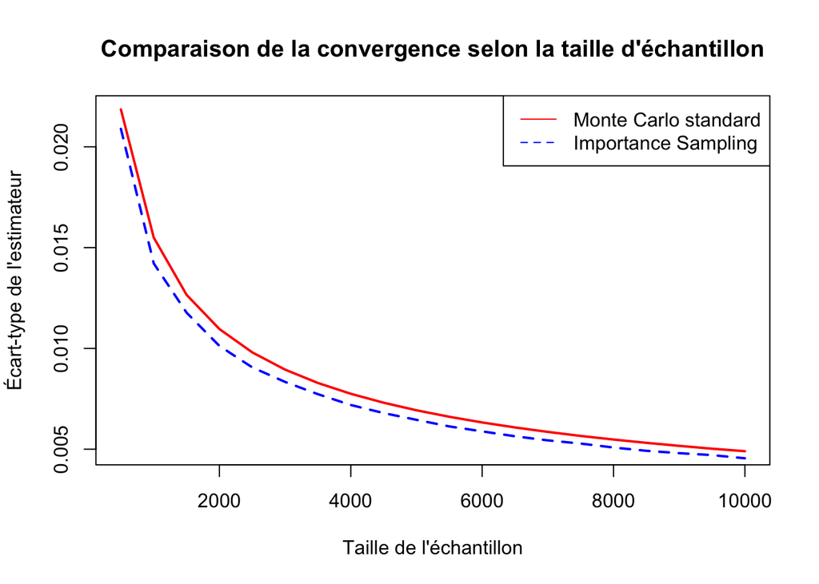

```r
# Analyse de convergence selon la taille d'échantillon
sample_sizes <- seq(500, 10000, by = 500)
std_errors_standard <- c()
std_errors_importance <- c()

set.seed(42)
for (n_paths in sample_sizes) {
  # Génération des incréments de mouvements browniens corrélés
  W1 <- matrix(rnorm(n_steps * n_paths), nrow = n_steps)
  W2 <- matrix(rnorm(n_steps * n_paths), nrow = n_steps)
  Z1 <- W1
  Z2 <- rho * W1 + sqrt(1 - rho^2) * W2

  # Simulation Monte Carlo standard
  S_nom <- matrix(0, nrow = n_steps + 1, ncol = n_paths)
  v_nom <- matrix(0, nrow = n_steps + 1, ncol = n_paths)
  S_nom[1, ] <- S_0
  v_nom[1, ] <- v0

  # Simulation avec importance sampling
  S_imp <- matrix(0, nrow = n_steps + 1, ncol = n_paths)
  v_imp <- matrix(0, nrow = n_steps + 1, ncol = n_paths)
  S_imp[1, ] <- S_0
  v_imp[1, ] <- v0

  # Simulation des trajectoires
  for (i in 1:n_steps) {
    # Monte Carlo standard
    v_nom[i+1, ] <- v_nom[i, ] + alpha*(m - v_nom[i, ])*dt + nu*sqrt(2*alpha)*sqrt(dt)*Z2[i, ]
    v_nom[i+1, ] <- pmax(v_nom[i+1, ], 0)
    S_nom[i+1, ] <- S_nom[i, ] * exp((r - 0.5*v_nom[i, ])*dt + sqrt(v_nom[i, ]*dt)*Z1[i, ])

    # Importance sampling
    v_imp[i+1, ] <- v_imp[i, ] + alpha*(m - v_imp[i, ])*dt + nu*sqrt(2*alpha)*sqrt(dt)*Z2[i, ]
    v_imp[i+1, ] <- pmax(v_imp[i+1, ], 0)
    S_imp[i+1, ] <- S_imp[i, ] * exp((r + mu_shift - 0.5*v_imp[i, ])*dt + sqrt(v_imp[i, ]*dt)*Z1[i, ])
  }

  # Calcul des payoffs et poids
  payoff_nom <- as.numeric(S_nom[n_steps + 1, ] > K)
  payoff_imp <- as.numeric(S_imp[n_steps + 1, ] > K)
  weights <- exp(-mu_shift * colSums(Z1) * sqrt(dt) + 0.5 * mu_shift^2 * T)

  # Calcul des écarts-types
  std_errors_standard <- c(std_errors_standard,
                          sd(exp(-r*T) * payoff_nom) / sqrt(n_paths))
  std_errors_importance <- c(std_errors_importance,
                            sd(exp(-r*T) * payoff_imp * weights) / sqrt(n_paths))
}

# Tracé de la convergence
plot(sample_sizes, std_errors_standard, type="l", col="red", lwd=2,
     xlab="Taille de l'échantillon", ylab="Écart-type de l'estimateur",
     main="Comparaison de la convergence selon la taille d'échantillon")
lines(sample_sizes, std_errors_importance, col="blue", lwd=2, lty=2)
legend("topright", legend=c("Monte Carlo standard", "Importance Sampling"),
       col=c("red", "blue"), lty=c(1,2))
```

```r
# Interprétation: On observe que l'écart-type décroît avec l'augmentation de la taille
# d'échantillon pour les deux méthodes, mais l'importance sampling maintient
# un avantage constant, offrant une meilleure précision à taille d'échantillon égale
```

## 4.2 Convergence en échelle log-log

L’échelle log-log permet de visualiser la convergence en puissance et de vérifier la pente de -1/2 attendue théoriquement:

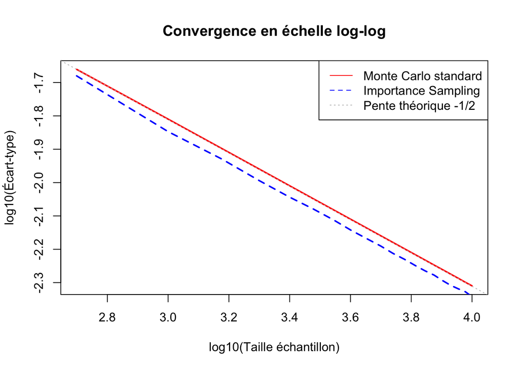

```r
# Analyse en échelle log-log
plot(log10(sample_sizes), log10(std_errors_standard), type="l", col="red", lwd=2,
     xlab="log10(Taille échantillon)", ylab="log10(Écart-type)",
     main="Convergence en échelle log-log")
lines(log10(sample_sizes), log10(std_errors_importance), col="blue", lwd=2, lty=2)

# Ligne de référence théorique (pente -1/2)
ref_a <- log10(std_errors_standard[1]) - (-0.5) * log10(sample_sizes[1])
abline(a = ref_a, b = -0.5, col="gray", lty=3)

legend("topright", legend=c("Monte Carlo standard", "Importance Sampling", "Pente théorique -1/2"),
       col=c("red", "blue", "gray"), lty=c(1,2,3))
```

# 5. Conclusion

## 5.2 Liens avec le cours MAT4372

Cette étude applique plusieurs concepts fondamentaux vus en cours: - Modélisation par processus stochastiques (OU pour la volatilité) - Théorème de Girsanov pour le changement de mesure - Simulation des EDS par méthode d’Euler - Technique de réduction de variance par échantillonnage préférentiel

## 5.3 Extensions possibles

Pour approfondir mon exploration pratique, il serait intéressant d’essayer: - D’implémenter la solution complète avec expansion asymptotique telle que proposée par Fouque & Tullie - De comparer avec d’autres techniques de réduction de variance (variables antithétiques, variables de contrôle) - D’étendre l’analyse à d’autres types d’options exotiques (barrière, asiatique, lookback) - D’étudier des modèles plus complexes (p.ex. avec sauts)

### 5.4 Apports personnels de cette démarche

Cette étude m’a permis de: - Confronter théorie et pratique numérique - Mieux comprendre les subtilités du changement de mesure - Développer une intuition plus fine sur le rôle de la volatilité stochastique - Évaluer quantitativement l’efficacité des méthodes de réduction de variance

# Références

- Boire, F.-M. (2025). *MAT 4372 Financial Mathematics: Lectures 18 and 19*. Department of Mathematics and Statistics, University of Ottawa.
- Fouque, J.-P., & Andrew Tullie, T. (2002). Variance reduction for Monte Carlo simulation in a stochastic volatility environment. Quantitative Finance, 2(1), 24–30. https://doi.org/10.1088/1469-7688/2/1/302
- Hull, J. (2018). Options, futures, and other derivatives (10th ed., pp. 491–510). Pearson.
- Shreve, S. E. (2010). Stochastic calculus for finance II: Continuous-time models (pp. 288–290, 450). Springer.
- Racicot, F.-É., & Théoret, R. (2006). Finance computationnelle et gestion des risques: Ingénierie financière avec applications Excel (Visual Basic) et Matlab. PU Québec. https://doi.org/10.14375/NP.9782760519121

# Annexe : Convergence de l’estimateur Monte Carlo

## Fondements mathématiques de la convergence en $\mathcal{O}(1/\sqrt{N})$

En vertu du Théorème Central Limite (TCL), si $X_1, X_2, \ldots, X_N$ sont des variables aléatoires indépendantes et identiquement distribuées (i.i.d.) avec une moyenne $\mu$ et une variance finie $\sigma^2$, alors la moyenne empirique :

$$\bar{X}_N=\frac{1}{N} \sum_{i=1}^N
X_i$$

converge en distribution vers une loi normale lorsque $N$ tend vers l’infini :

$$\sqrt{N}\left(\bar{X}_N-\mu\right)
\xrightarrow{d} \mathcal{N}\left(0, \sigma^2\right)$$

On peut réarranger cette expression pour obtenir :

$$\bar{X}_N-\mu \approx
\mathcal{N}\left(0, \frac{\sigma^2}{N}\right)$$

Ce qui nous montre que l’écart-type de l’estimateur est :

$$\text{Écart-type}=\frac{\sigma}{\sqrt{N}}$$

Donc, lorsqu’on estime l’espérance d’une variable aléatoire (comme le prix d’une option) par simulation Monte Carlo, on génère $N$ réalisations indépendantes et on calcule leur moyenne empirique. Le TCL nous permet d’établir que l’erreur de cette estimation décroît proportionnellement à $1/\sqrt{N}$.

## Implications pratiques

Dans le cadre de l’évaluation d’options, cette convergence en $O(1/\sqrt{N})$ implique :

1. Pour réduire l’erreur d’estimation par un facteur $k$, le nombre de simulations doit être multiplié par $k^2$
2. Intervalle de confiance à $95%$ : $\bar{X}_N \pm 1.96 \times \frac{\sigma}{\sqrt{N}}$

Cela justifie la recherche de techniques de réduction de variance comme celle proposée par Fouque & Tullie (2001), qui permettent d’obtenir une même précision avec significativement moins de simulations.

## Illustration empirique : pente de -1/2 en échelle log-log

J’ai voulu recourir à une méthode simple pour vérifier empiriquement la convergence en $\mathcal{O}(1/\sqrt{N})$. Comme il est courant de représenter l’écart-type estimé en fonction de la taille de l’échantillon sur une échelle log-log, j’ai tracé cette relation afin d’observer la pente théorique attendue.

- Si l’erreur décroît bien comme $1/\sqrt{N}$, on doit observer une pente proche de **-1/2** sur le graphique log-log.
- Ce test visuel permet de confirmer que la simulation respecte le comportement asymptotique prévu par le TCL.
- Dans mon cas, les deux méthodes (standard et importance sampling) affichent une pente cohérente avec la théorie, ce qui renforce la crédibilité des résultats obtenus.